# Data Visualization using `ggplot()`

### Categorical Variable vs. Numerical Variable

To describe the relationship between a categorical and a numerical variable, use side-by-side box plots. Does the bill length of a penguin change based on its species? Recall from earlier that, at a minimum, a boxplot requires an `x` aesthetic. Here we will pass it both an `x` and `y` aesthetic, where `x` is a grouping variable (categorical) and `y` is the numerical variable we are interested in visualizing across the groups.

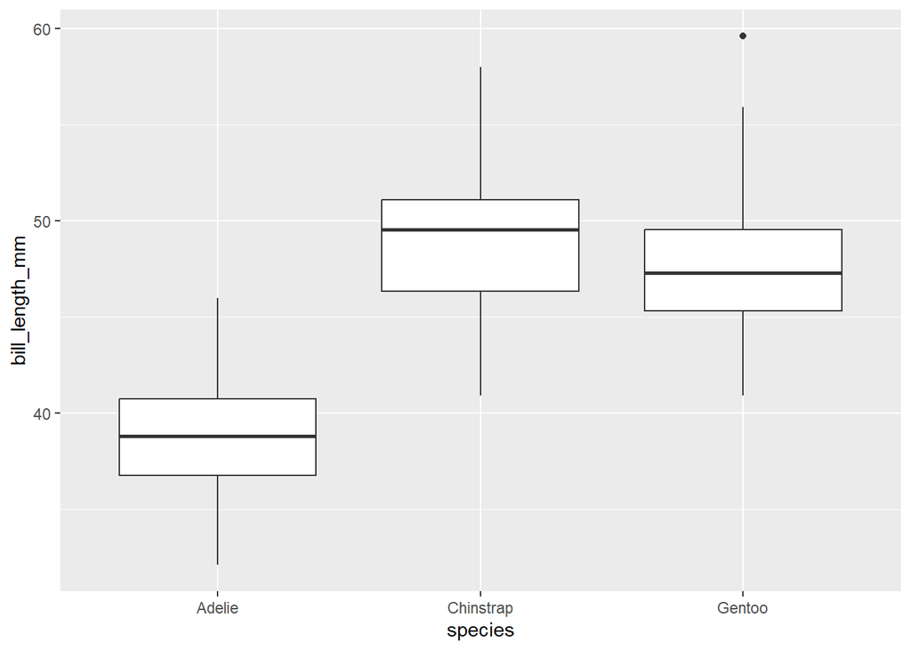

```r
penguins %>%
  filter(!is.na(bill_length_mm)) %>%
  ggplot() +
  geom_boxplot(aes(x = species, y = bill_length_mm))
```

We can also use violin plots to visualize the relationship. Violin plots are sort of a mash-up between a box plot and a histogram, where the sides of the violin plot are smoothed versions of the bars from the histogram of the data. The width of the violin plot corresponds to the proportion of the data that falls within that range.

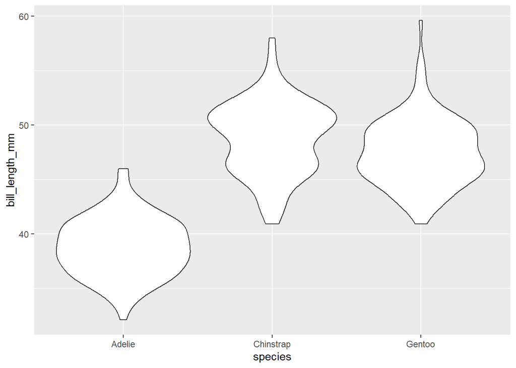

```r
penguins %>%
  filter(!is.na(bill_length_mm)) %>%
  ggplot() +
  geom_violin(aes(x = species, y = bill_length_mm))
```

### Categorical Variable vs. Categorical Variable

To visualize the relationship between two categorical variables, you can use stacked bar plots or mosaic plots. A stacked bar plot separates the bars of a bar plot according to the values of the second categorical variable. For example, we can plot the species of a penguin against its sex by adding the `fill = sex` aesthetic:

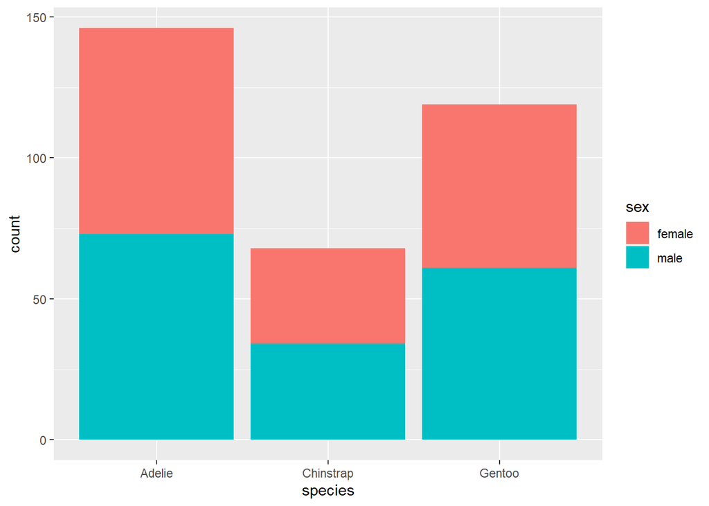

```r
penguins %>%
  filter(!is.na(sex)) %>%
  ggplot() +
  geom_bar(aes(x = species, fill = sex))
```

A mosaic plot creates largely the same graphic, but makes it easier to see the proportions of each level of one variable that belong to a level of the other variable. The width of each box corresponds to the proportion of the overall dataset which has values that lie in the intersection of those variables. From the mosaic plot, we can see that males are slightly over-represented among `Gentoo` penguins relative to the other species. The code below requires installing and loading the `ggmosaic` package. Notice also that the aesthetic argument is also slightly different for mosaic plots. The variables which you would like to have plotted against each other should be wrapped in a `product()` function within the aesthetics for `geom_mosaic()` layer.

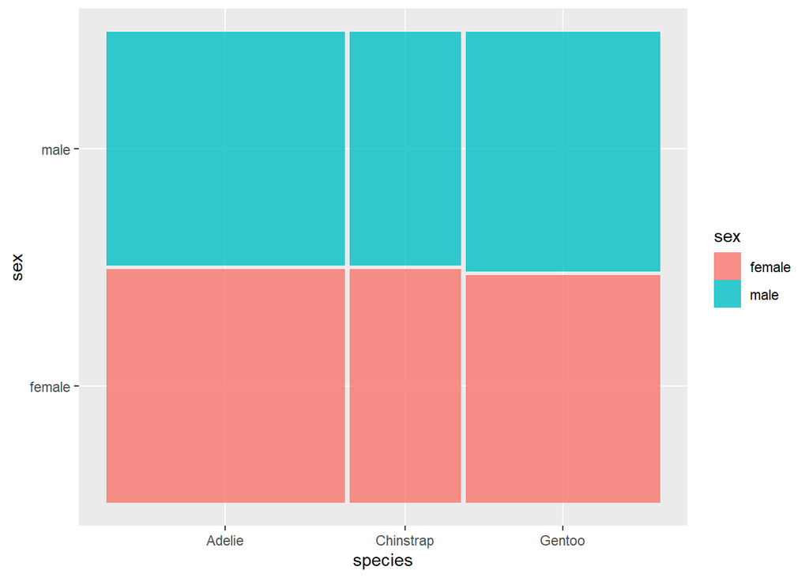

```r
library(ggmosaic)
penguins %>%
  filter(!is.na(sex)) %>%
  ggplot() +
  geom_mosaic(aes(product(sex,species), fill = sex))
```

### Using the Wrong Type of Plot

It is certainly not the end of the world if you choose a type of plot that is not appropriate for the variables that you are considering, but it is an important skill to be able to identify when an inappropriate plot has been created. I would like to give you some examples of poorly chosen plots, where the plots do not provide the reader with very much (or any) information:

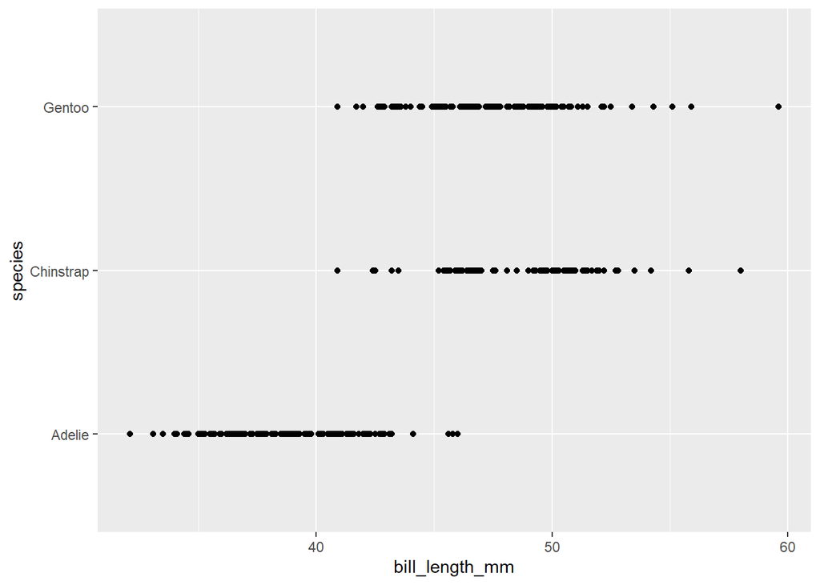

```r
penguins %>%
  filter(!is.na(species)) %>%
  ggplot() +
  geom_point(aes(x = bill_length_mm, y = species))
```

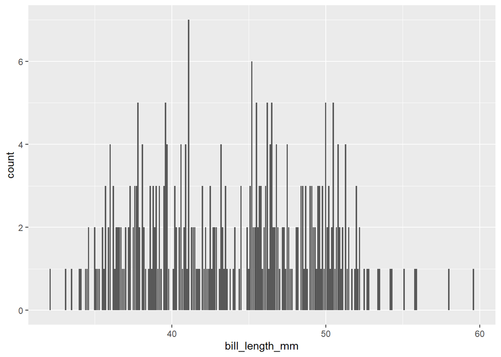

```r
penguins %>%
  ggplot() +
  geom_bar(aes(x = bill_length_mm))
```

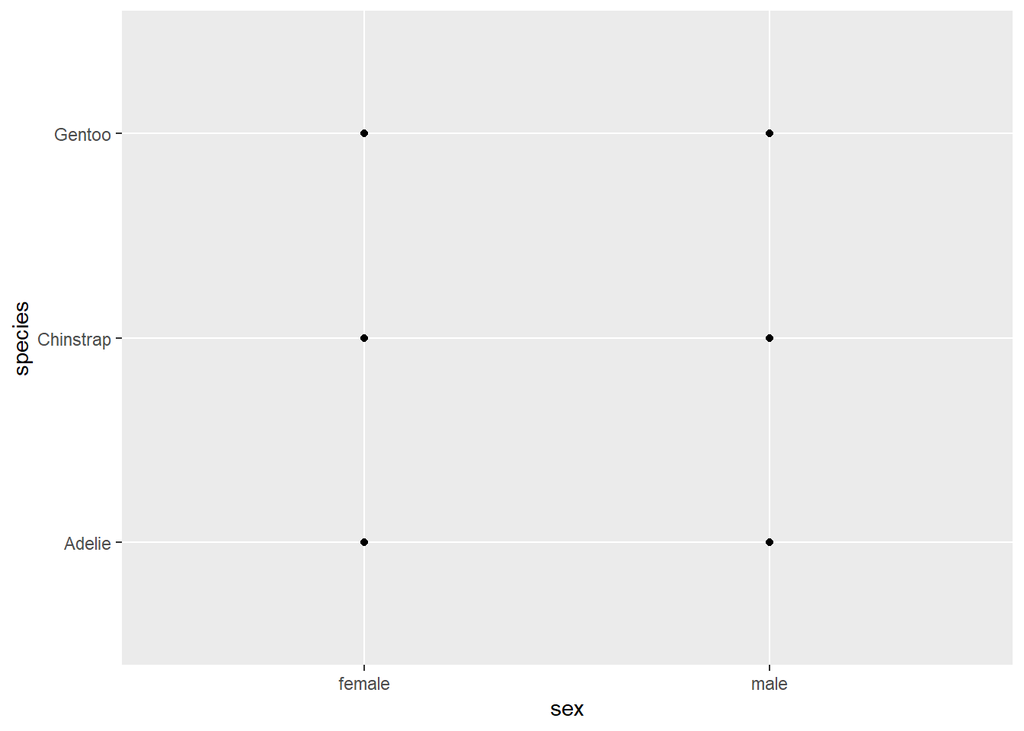

```r
penguins %>%
  filter(!is.na(sex)) %>%
  ggplot() +
  geom_point(aes(x = sex, y = species))
```

From the examples above, you should see that understanding the type of variable that you are considering is an important part of data visualization!

## Tricking Out Your Plots

There are many options for plot customization! One of the most common customizations is in the axis labels and plot title, which can be controlled with the `labs()` layer. Additionally, if you are building a plot with multiple layers, and those layers share common aesthetics, you can place the aesthetics into the original `ggplot()` call rather than duplicating them across the geometry layers.

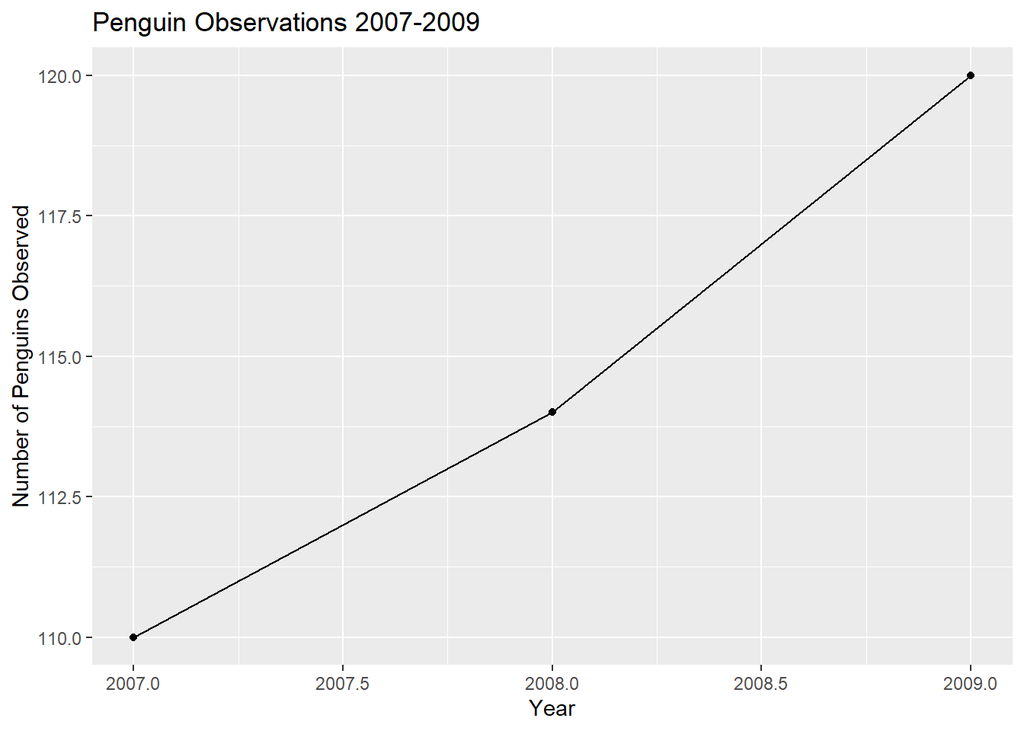

```r
penguins %>%
  count(year) %>%
  ggplot(aes(x = year, y = n)) +
  geom_line() +
  geom_point() +
  labs(x = "Year", y = "Number of Penguins Observed", title = "Penguin Observations 2007-2009")
```

The tick marks in this plot are not great, since it doesn’t make (from an animal cruelty perspective) sense to consider half of a penguin. We can adjust the tick marks using the `scale_x_continuous()` and `scale_y_continuous()` layers. The `breaks =` argument takes a list of the tick marks that you would like the axis to have. The `seq()` function has the syntax `seq(min, max, by)` and creates a list of numbers from `min` to `max` counting by increments sized according to the `by` argument.

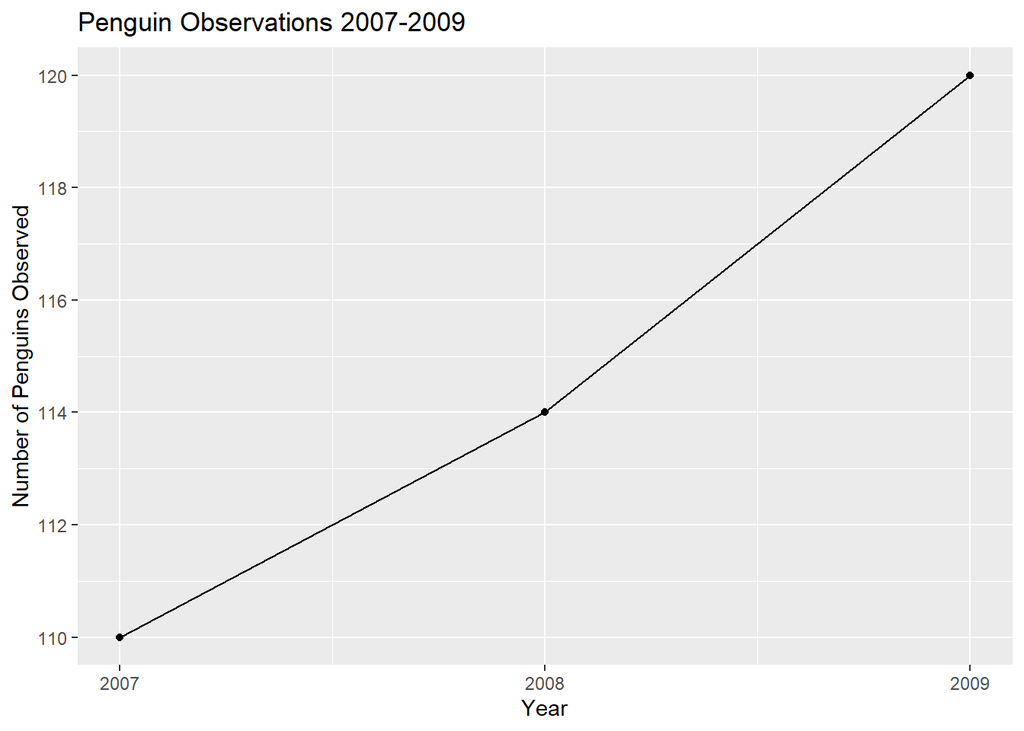

```r
penguins %>%
  count(year) %>%
  ggplot(aes(year, n)) +
  geom_line() +
  geom_point() +
  scale_x_continuous(breaks = seq(2007,2009,1)) +
  scale_y_continuous(breaks = seq(110,120,2)) +
  labs(x = "Year", y = "Number of Penguins Observed") +
  ggtitle("Penguin Observations 2007-2009")
```

It is also easy to make separate plots for each of the species of penguin, using the `color` aesthetic,

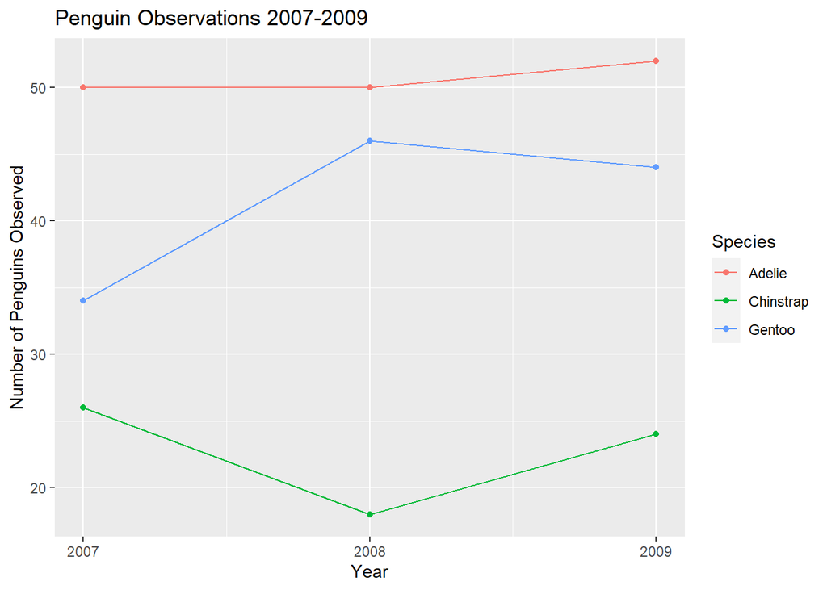

```r
penguins %>%
  count(year, species) %>%
  ggplot(aes(year, n, color = species)) +
  geom_line() +
  geom_point() +
  scale_x_continuous(breaks = seq(2007,2009,1)) +
  scale_y_continuous(breaks = seq(10,60,10)) +
  labs(x = "Year", y = "Number of Penguins Observed", color = "Species") +
  ggtitle("Penguin Observations 2007-2009")
```

or by the sex of the penguin. In this case, I used a `scale_color_discrete()` layer to adjust the labels of the levels of the `sex` variable to capitalize them, and change `NA` to “Unknown”. Notice that we passed two columns to the `count()` function here, indicating that we wanted counts computed for each unique combination of `sex` and `year`.

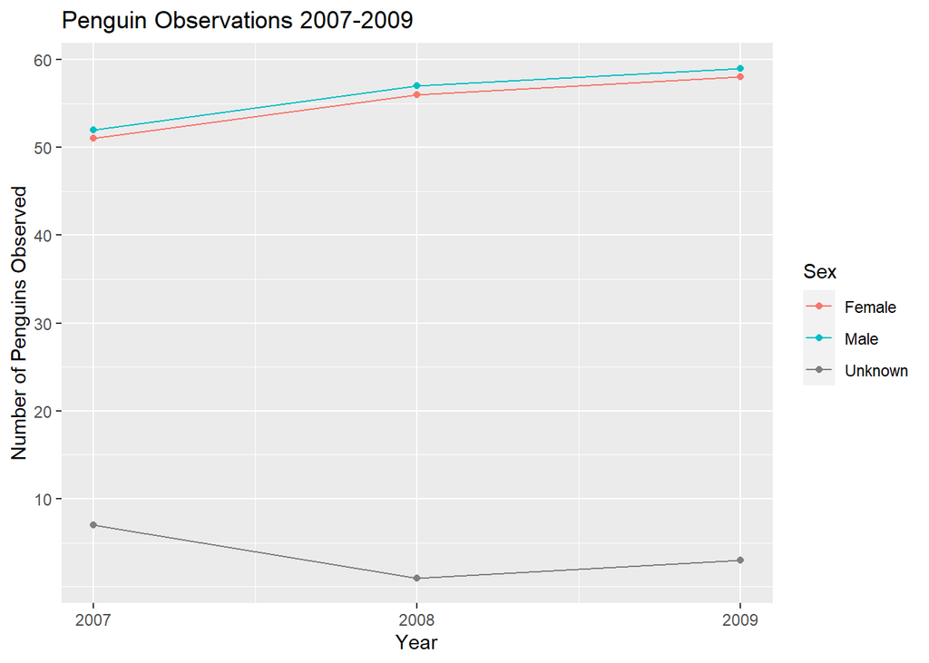

```r
penguins %>%
  count(year, sex) %>%
  ggplot(aes(year, n, color = sex)) +
  geom_line() +
  geom_point() +
  scale_x_continuous(breaks = seq(2007,2009,1)) +
  scale_y_continuous(breaks = seq(10,60,10)) +
  scale_color_discrete(labels = c("Female","Male","Unknown")) +
  labs(x = "Year", y = "Number of Penguins Observed", color = "Sex") +
  ggtitle("Penguin Observations 2007-2009")
```

It is also possible to make separate plots for each level of a categorical variable, using a `facet_grid()` layer.

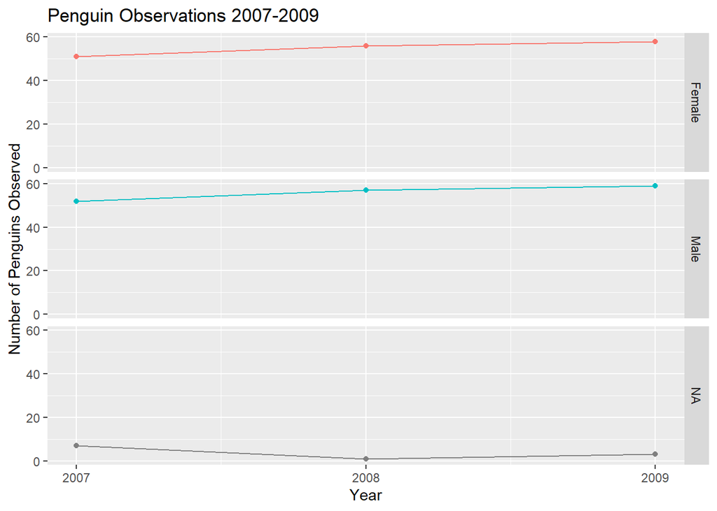

```r
penguins %>%
  count(year, sex) %>%
  ggplot(aes(year, n, color = sex)) +
  geom_line(show.legend = FALSE) +
  geom_point(show.legend = FALSE) +
  facet_grid(sex~., labeller = as_labeller(c(female = "Female", male = "Male"))) +
  scale_x_continuous(breaks = seq(2007,2009,1)) +
  labs(x = "Year", y = "Number of Penguins Observed") +
  ggtitle("Penguin Observations 2007-2009")
```

## Final Thoughts

I’ve given you a ton of information here- please don’t feel overwhelmed! I am intending this document to be a place that you can come back to reference and copy and paste from. There is also a lot of support online through the [`ggplot2` documentation](https://ggplot2.tidyverse.org/reference/), the [R Graph Gallery](https://www.r-graph-gallery.com/), and sites like Stack Overflow where you can get additional information and tips on creating data visualizations using R. If you want a full course on tricking out your plots with `ggplot()`, check out [this extensive tutorial](https://www.cedricscherer.com/2019/08/05/a-ggplot2-tutorial-for-beautiful-plotting-in-r/) from Ced Scherer.